# Assigment 1a

Zulikah Latief (s4273281)

22/11/2021

### PART I: Data inspection

**Question 1: Read the data into a data frame**

```r
#load data
data <- read.table('C:/Users/user/Documents/MSC AI/MSC AI YEAR 2/Adv stats/R programming/s4273281_assignment1a/data.txt', header=TRUE)

#check missing values
sum(is.na(data))
```

```
## [1] 0
```

**Inspect the data: What are the names of the columns? How many rows are in the data?**

```r
head(data)
```

```
##   Subject Age Condition    Item Frequency Rating
## 1    s140  53    Study1 Item129       210      5
## 2    s140  53    Study1 Item172       135      5
## 3    s140  53    Study1 Item165       510      5
## 4    s140  53    Study1 Item011       952      5
## 5    s140  53    Study1 Item074       492      5
## 6    s140  53    Study1 Item121       437      5
```

There are a total of 34,182 rows and 6 columns, namely, Subject, Age, Condition, Item, Frequency and Rating.

**Inspect the data and try to understand what each column represent. Note: You can ignore the column ‘Frequency’ in this Assignment.**

The subject represents the participants of the experiment and the age represents their respective age. The experiment itself has two conditions, namely, study1 and study2. Furthermore, the study involves items that need to be rated on a scale of 1 to 5.

**Describe the structure of the data set: What is the design (between subjects design, within subjects design)? Also provide a summary of the values in each column (i.e., type of data, range of values, number of different values, etc).**

Structure of data - long table. Study1 was conducted on all the 257 subjects. Whereas Study2 was conducted on only s001 to s105. However, it is important to note that the subjects in study2 were different people. For instance, this can be seen by looking at the age of the subject s001, which differs across the two conditions.

```r
head(data[data$Subject=='s001',])
```

```
##       Subject Age Condition    Item Frequency Rating
## 12243    s001  71    Study1 Item129       210      2
## 12244    s001  71    Study1 Item172       135      5
## 12245    s001  71    Study1 Item165       510      4
## 12246    s001  71    Study1 Item011       952      4
## 12247    s001  71    Study1 Item074       492      4
## 12248    s001  71    Study1 Item121       437      4
```

```r
tail(data[data$Subject=='s001',])
```

```
##       Subject Age Condition    Item Frequency Rating
## 26580    s001  60    Study2 Item161        84      5
## 26581    s001  60    Study2 Item082      1582      5
## 26582    s001  60    Study2 Item045       327      5
## 26583    s001  60    Study2 Item071       293      5
## 26584    s001  60    Study2 Item102      3153      5
## 26585    s001  60    Study2 Item169       852      5
```

Therefore, different people took part in each condition and this makes the design of the experiment a between-subject design.

```r
#Summary of the variables
summary(data)
```

```
##    Subject               Age         Condition             Item
##  Length:34182       Min.   :12.00   Length:34182       Length:34182
##  Class :character   1st Qu.:25.00   Class :character   Class :character
##  Mode  :character   Median :35.00   Mode  :character   Mode  :character
##                     Mean   :39.09
##                     3rd Qu.:52.00
##                     Max.   :86.00
##    Frequency          Rating
##  Min.   :   0.0   Min.   :1.000
##  1st Qu.:  81.0   1st Qu.:4.000
##  Median : 241.0   Median :5.000
##  Mean   : 422.7   Mean   :4.383
##  3rd Qu.: 541.0   3rd Qu.:5.000
##  Max.   :4688.0   Max.   :5.000
```

**If you would need to make a graph summarizing this data, what type of graph would you choose?**

A scatter plot will be used for summarizing the data. This clearly represents the relationship between the age variable and the ratings variable.

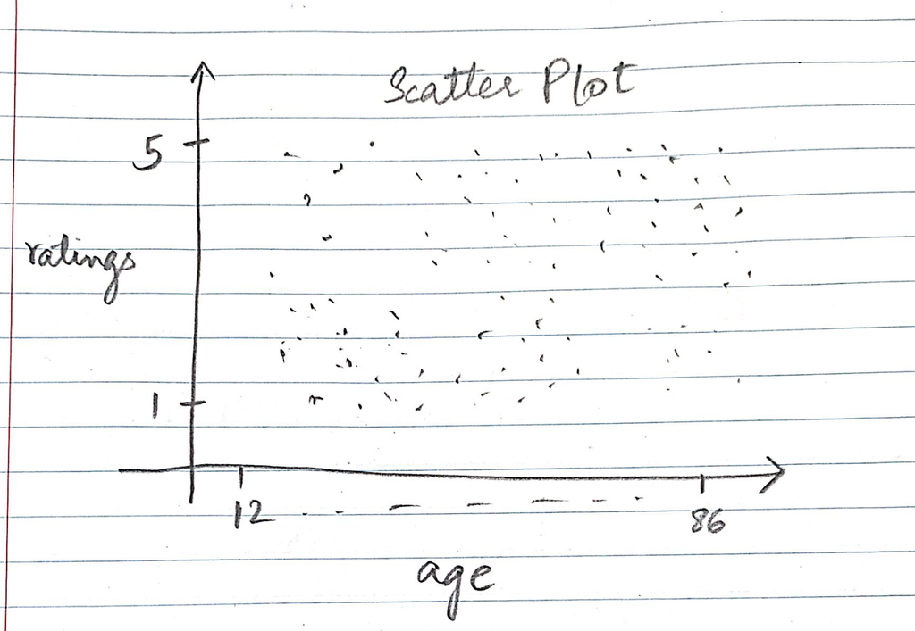

Scatter plot

### PART II: Descriptive Statistics

**Question 4: Summarise the data in the columns ‘Age’, ‘Rating’, and ‘Condition’. Which statistics do you report? (Note that we’re asking here for the descriptive statistics of the variables and their interactions rather than the unique values or range of values, as was asked in Question 2.)

```r
#Splitting data by condition
dat_exp1 <- subset(data, Condition == "Study1", select = c("Subject","Age","Rating", "Condition"))
dat_exp2 <- subset(data, Condition == "Study2", select = c("Subject","Age","Rating", "Condition"))
```

*Summarizing Age variable for different condition*

```r
#Check mean and median for condition study1
summary(dat_exp1$Age)
```

```
##    Min. 1st Qu.  Median    Mean 3rd Qu.    Max.
##   12.00   24.00   30.00   37.66   51.00   86.00
```

```r
#Check mean and median for condition study2
summary(dat_exp2$Age)
```

```
##    Min. 1st Qu.  Median    Mean 3rd Qu.    Max.
##   19.00   28.00   42.00   43.32   57.00   76.00
```

```r
#Calculate mode
mode_var <- function(variable) {
   unique_var <- unique(variable)
   unique_var[which.max(tabulate(match(variable, unique_var)))]
}

#Check mode for condition study1
mode_var(dat_exp1$Age)
```

```
## [1] 24
```

```r
#Check mode for condition study2
mode_var(dat_exp2$Age)
```

```
## [1] 27
```

Measures of Central tendency: Even though the range of the age variable is between 12 and 86 for study1, the mean and median is 37.6 and 30 respectively.It can also be noted that the age variable is imbalanced as it does not have equal number of subjects for all the age groups. On the other hand, the age of subjects in study2 is in the range of 19 and 76. The median and mean is at 42 and 43.32 respectively. The mode age for study1 is 24 and for study2 it is 27.

```r
#Calculate mean absolute deviation for condition study1
X <- dat_exp1$Age
X.bar <- mean( X )
AD <- abs( X - X.bar )
AAD <- mean( AD )
print( AAD )
```

```
## [1] 15.19089
```

```r
#Calculate mean absolute deviation for condition study2
X <- dat_exp2$Age
X.bar <- mean( X )
AD <- abs( X - X.bar )
AAD <- mean( AD )
print( AAD )
```

```
## [1] 12.75896
```

```r
#Calculate median absolute deviation for condition study1
mad(dat_exp1$Age)
```

```
## [1] 14.826
```

```r
#Calculate median absolute deviation for condition study2
mad(dat_exp2$Age)
```

```
## [1] 20.7564
```

```r
#Calculate IQR for condition study1
range(dat_exp1$Age, na.rm=TRUE)
```

```
## [1] 12 86
```

```r
IQR(dat_exp1$Age)
```

```
## [1] 27
```

```r
#Calculate IQR for condition study2
range(dat_exp2$Age, na.rm=TRUE)
```

```
## [1] 19 76
```

```r
IQR(dat_exp2$Age)
```

```
## [1] 29
```

```r
#Calculate standard deviation for condition study1
sd(dat_exp1$Age)
```

```
## [1] 17.40113
```

```r
#Calculate standard deviation for condition study2
sd(dat_exp2$Age)
```

```
## [1] 14.52153
```

Measure of variability: The absolute deviation of the age variable from the mean and median is calculated for both the conditions. For study 1, mean absolute deviation is 15.19089 and Median absolute deviation is 14.826. The IQR of the age variable is 27 and the standard deviation is 17.40113. For study2, mean absolute deviation is 12.75896 and Median absolute deviation is 20.7564 The IQR of the age variable is 29 and the standard deviation is 14.52153.

```r
#Fit normal distribution for study1
library(fitdistrplus)
fit <- fitdistr(dat_exp1$Age, "normal")
class(fit)
```

```
## [1] "fitdistr"
```

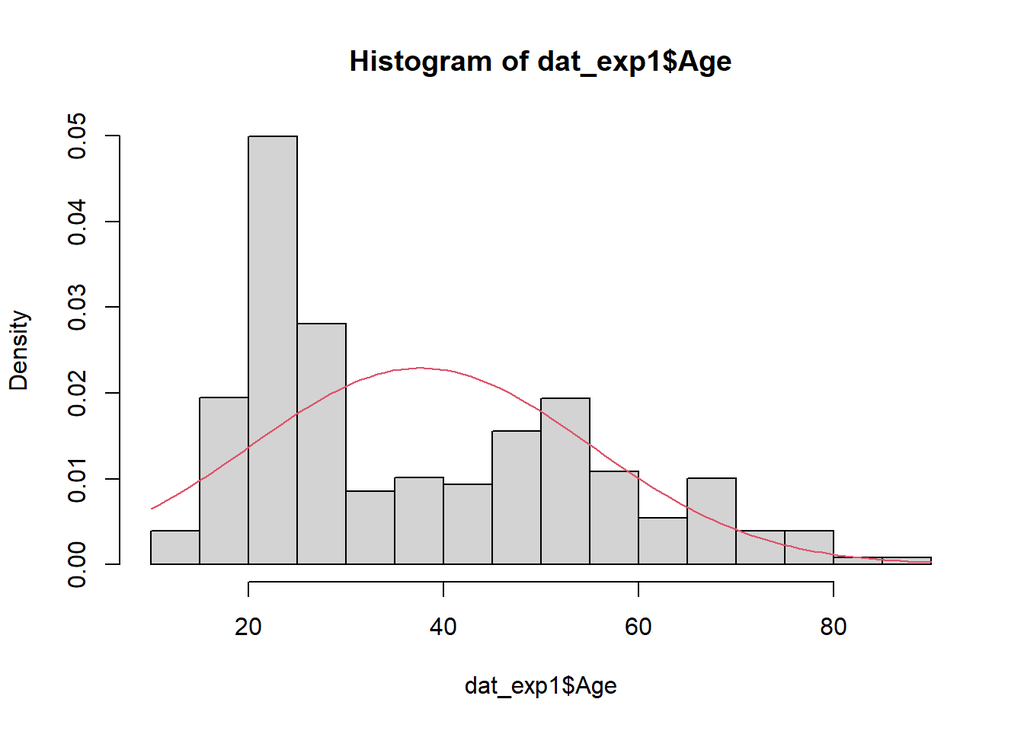

```r
para <- fit$estimate
hist(dat_exp1$Age, prob = TRUE)
curve(dnorm(x, para[1], para[2]), col = 2, add = TRUE)
```

```r
#Fit normal distribution for study2
library(fitdistrplus)
fit <- fitdistr(dat_exp2$Age, "normal")
class(fit)
```

```
## [1] "fitdistr"
```

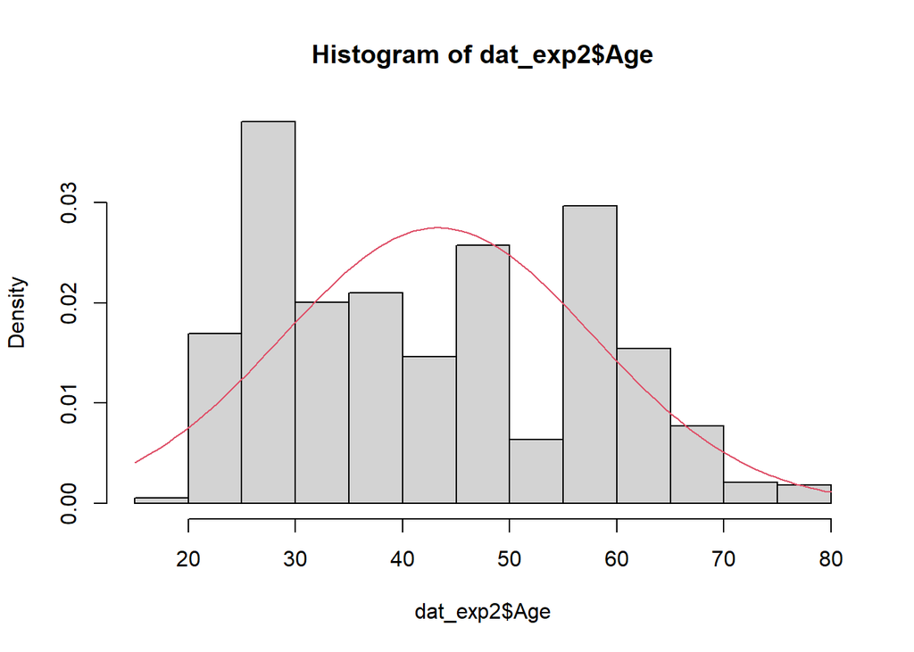

```r
para <- fit$estimate
hist(dat_exp2$Age, prob = TRUE)
curve(dnorm(x, para[1], para[2]), col = 2, add = TRUE)
```

```r
#Calculate skewness for study1
library(moments)
skewness(dat_exp1$Age)
```

```
## [1] 0.68579
```

```r
#Calculate skewness for study2
library(moments)
skewness(dat_exp2$Age)
```

```
## [1] 0.2755479
```

Understanding the distribution: For study1 and study2, the distribution of the age variable is shown in the plot. In study1, most of the data is concentrated on the left of the mean value (right-skewed). This was evident in the unbalanced number of subjects per age group. Furthermore, this is confirmed by checking the skewness for study 1. In the case of study2, the distribution is closer to a normal distribution. However, there is slight skewness (right-skewed), which shows more number of subjects in study2 are between 20-30 years of age.

*Summarizing Ratings variable for each condition*

```r
#Check mean and median for study1
summary(dat_exp1$Rating)
```

```
##    Min. 1st Qu.  Median    Mean 3rd Qu.    Max.
##   1.000   4.000   5.000   4.427   5.000   5.000
```

```r
#Check mean and median for study2
summary(dat_exp2$Rating)
```

```
##    Min. 1st Qu.  Median    Mean 3rd Qu.    Max.
##   1.000   4.000   5.000   4.251   5.000   5.000
```

```r
#calculate mode for study1
mode_var(dat_exp1$Rating)
```

```
## [1] 5
```

```r
#calculate mode for study2
mode_var(dat_exp2$Rating)
```

```
## [1] 5
```

```r
#Calculate mean absolute deviation for study1
X <- dat_exp1$Rating
X.bar <- mean( X )
AD <- abs( X - X.bar )
AAD <- mean( AD )
print( AAD )
```

```
## [1] 0.822262
```

```r
#Calculate mean absolute deviation for study2
X <- dat_exp2$Rating
X.bar <- mean( X )
AD <- abs( X - X.bar )
AAD <- mean( AD )
print( AAD )
```

```
## [1] 0.9977526
```

```r
#Calculate median absolute deviation for study1
mad(dat_exp1$Rating)
```

```
## [1] 0
```

```r
#Calculate median absolute deviation for study2
mad(dat_exp2$Rating)
```

```
## [1] 0
```

```r
#Calculate IQR for study1
range(dat_exp1$Rating, na.rm=TRUE)
```

```
## [1] 1 5
```

```r
IQR(dat_exp1$Rating)
```

```
## [1] 1
```

```r
#Calculate IQR for study2
range(dat_exp2$Rating, na.rm=TRUE)
```

```
## [1] 1 5
```

```r
IQR(dat_exp2$Rating)
```

```
## [1] 1
```

```r
#Calculate standard deviation for study1
sd(dat_exp1$Rating)
```

```
## [1] 1.095866
```

```r
#Calculate standard deviation for study2
sd(dat_exp2$Rating)
```

```
## [1] 1.258073
```

```r
#Fit normal distribution for study1
fit <- fitdistr(dat_exp1$Rating, "normal")
class(fit)
```

```
## [1] "fitdistr"
```

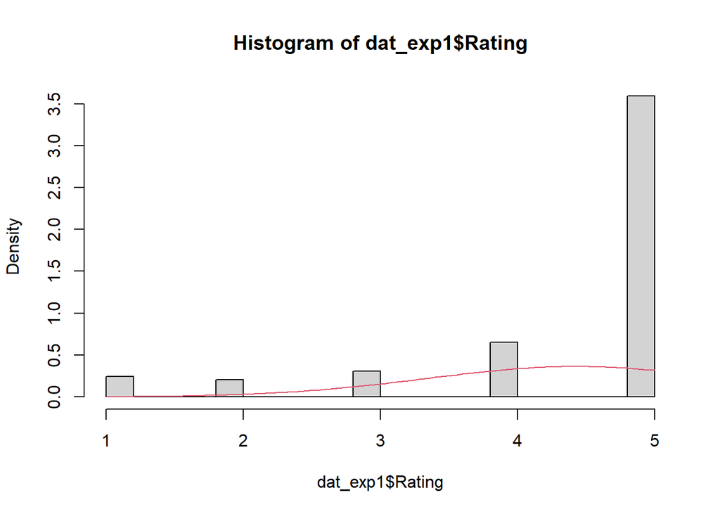

```r
para <- fit$estimate
hist(dat_exp1$Rating, prob = TRUE)
curve(dnorm(x, para[1], para[2]), col = 2, add = TRUE)
```

```r
#Fit normal distribution for study2
fit <- fitdistr(dat_exp2$Rating, "normal")
class(fit)
```

```
## [1] "fitdistr"
```

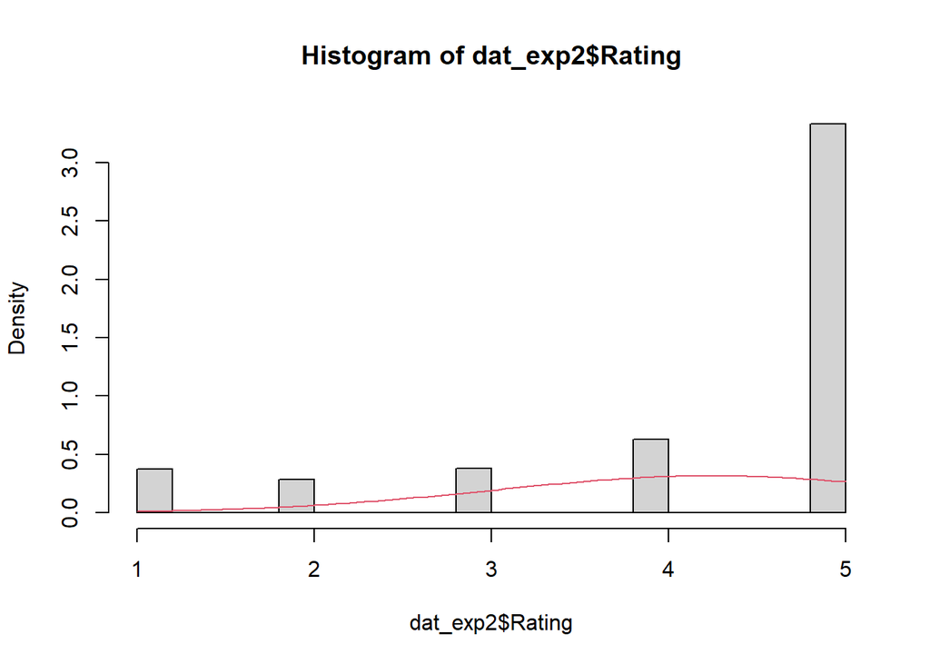

```r
para <- fit$estimate
hist(dat_exp2$Rating, prob = TRUE)
curve(dnorm(x, para[1], para[2]), col = 2, add = TRUE)
```

```r
#Calculate skewness for study1
library(moments)
skewness(dat_exp1$Rating)
```

```
## [1] -1.981574
```

```r
#Calculate skewness for study2
library(moments)
skewness(dat_exp2$Rating)
```

```
## [1] -1.557222
```

For study1 and study2 he mean and median of the ratings variable is approximately the same, i.e., 4 and 5 respectively. The mode is 5. The absolute deviation of the ratings variable from the mean and median is calculated for study1 and study2. Mean absolute deviation is 0.822262 for study1 and 0.9977526 for study2. The Median absolute deviation is 0 for both conditions. The IQR of the ratings variable is 1 for both conditions and the standard deviation is 1.095866 for study1 and 1.258073 for study2. The distribution of the ratings variable for bith conditions is shown in the plot. Most of the data is concentrated on the right (left-skewed) for both conditions. Furthermore, this is confirmed by checking the skewness.

*Relationship between the age and ratings variable by condition*: Checking the correlation between age and ratings.

```r
cor(dat_exp1$Age, dat_exp1$Rating)
```

```
## [1] 0.2562665
```

```r
cor(dat_exp2$Age, dat_exp2$Rating)
```

```
## [1] 0.1687893
```

**Create a plot that you think best visualizes the data. Try to avoid using the packages ‘ggplot’ or ‘ggplot2’, but preferrably use basic plotfunctions.**

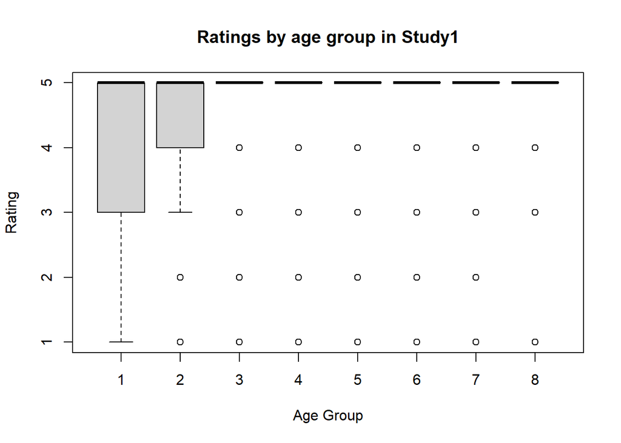

```r
#Split age variable into groups
data$Agegrp<-cut(data$Age, seq(10,90,10), labels=c(1:8))

#Subsetting data condition wise
dat_exp1 <- subset(data, Condition == "Study1", select = c("Agegrp","Rating","Subject", "Condition", "Age"))
dat_exp2 <- subset(data, Condition == "Study2", select = c("Agegrp","Rating","Subject", "Condition", "Age"))

#Box plot displaying the Age and Ratings variable in study1
plot(dat_exp1$Agegrp, dat_exp1$Rating, xlab="Age Group", ylab="Rating", main = "Ratings by age group in Study1")
```

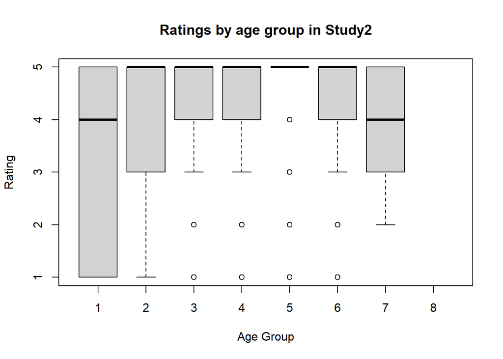

```r
#Box plot displaying the Age and Ratings variable in study2
plot(dat_exp2$Agegrp, dat_exp2$Rating, xlab="Age Group", ylab="Rating", main = "Ratings by age group in Study2")
```

**Calculate the average rating and the median rating for each individual participant using each of the three function (so calculate the same averages three times).**

```r
#Average rating per subject for study1 using tapply
avg_rating_s1 <- tapply(dat_exp1$Rating, list(dat_exp1$Subject), mean)
head(avg_rating_s1)
```

```
##     s001     s002     s003     s004     s005     s006
## 4.340000 4.890000 4.960000 4.909091 4.990000 4.880000
```

```r
#Average rating per subject for study2 using tapply
avg_rating_s2 <- tapply(dat_exp2$Rating, list(dat_exp2$Subject), mean)
head(avg_rating_s2)
```

```
##     s001     s002     s003     s004     s005     s006
## 4.670330 4.450549 4.791209 4.362637 4.461538 4.850575
```

```r
#Median rating per subject for study1 using tapply
median_rating_s1 <- tapply(dat_exp1$Rating, list(dat_exp1$Subject), median)
head(median_rating_s1)
```

```
## s001 s002 s003 s004 s005 s006
##    4    5    5    5    5    5
```

```r
#Median rating per subject for study2 using tapply
median_rating_s2 <- tapply(dat_exp2$Rating, list(dat_exp2$Subject), median)
head(median_rating_s2)
```

```
## s001 s002 s003 s004 s005 s006
##    5    5    5    5    5    5
```

```r
#Average rating per subject for study1 using aggregate
avg_rating_agg_s1 <- aggregate(dat_exp1$Rating, list(dat_exp1$Subject), mean)
head(avg_rating_agg_s1)
```

```
##   Group.1        x
## 1    s001 4.340000
## 2    s002 4.890000
## 3    s003 4.960000
## 4    s004 4.909091
## 5    s005 4.990000
## 6    s006 4.880000
```

```r
#Average rating per subject for study2 using aggregate
avg_rating_agg_s2 <- aggregate(dat_exp2$Rating, list(dat_exp2$Subject), mean)
head(avg_rating_agg_s2)
```

```
##   Group.1        x
## 1    s001 4.670330
## 2    s002 4.450549
## 3    s003 4.791209
## 4    s004 4.362637
## 5    s005 4.461538
## 6    s006 4.850575
```

```r
#Median rating per subject for study1 using aggregate
library('plyr')
median_rating_agg_s1 <- aggregate(dat_exp1$Rating, list(dat_exp1$Subject), median)
print(head(median_rating_agg_s1))
```

```
##   Group.1 x
## 1    s001 4
## 2    s002 5
## 3    s003 5
## 4    s004 5
## 5    s005 5
## 6    s006 5
```

```r
#Median rating per subject for study2 using aggregate
median_rating_agg_s2 <- aggregate(dat_exp2$Rating, list(dat_exp2$Subject), median)
print(head(median_rating_agg_s2))
```

```
##   Group.1 x
## 1    s001 5
## 2    s002 5
## 3    s003 5
## 4    s004 5
## 5    s005 5
## 6    s006 5
```

```r
#Average and median rating per subject for study1 using ddply
aggre_ddp_s1 <- ddply(dat_exp1, c('dat_exp1$Subject'), summarise,
                   avg = mean(Rating), median = median(Rating))
head(aggre_ddp_s1)
```

```
##   dat_exp1$Subject      avg median
## 1             s001 4.340000      4
## 2             s002 4.890000      5
## 3             s003 4.960000      5
## 4             s004 4.909091      5
## 5             s005 4.990000      5
## 6             s006 4.880000      5
```

```r
#Average and median rating per subject for study2 using ddply
aggre_ddp_s2 <- ddply(dat_exp2, c('dat_exp2$Subject'), summarise,
                   avg = mean(Rating), median = median(Rating))
head(aggre_ddp_s2)
```

```
##   dat_exp2$Subject      avg median
## 1             s001 4.670330      5
## 2             s002 4.450549      5
## 3             s003 4.791209      5
## 4             s004 4.362637      5
## 5             s005 4.461538      5
## 6             s006 4.850575      5
```

**What are the differences between the three functions?** The difference is in the format of the outputs. The tapply function returns an array, whereas the aggregate function returns a data frame. The ddply function is similar to the aggregate() in terms of the type of output returned, however, it accepts multiple parameters for calculating multiple measures.

```r
#Checking the output type
class(avg_rating_s1)
```

```
## [1] "array"
```

```r
class(avg_rating_agg_s1)
```

```
## [1] "data.frame"
```

```r
class(aggre_ddp_s1)
```

```
## [1] "data.frame"
```